# R markdown for naive-bayes algorhitm

## setup

```r
knitr::opts_knit$set(root.dir = 'C:/Users/אחיעד/Desktop/data science/ass2/prediction2')
getwd()
```

```
## [1] "C:/Users/אחיעד/Desktop/data science/ass2/prediction2"
```

## read train.csv into dataframe

```r
df <- read.csv("C:/Users/אחיעד/Desktop/data science/ass2/Titanic/train.csv",na.strings = "")
```

## using str to identify data types

```r
str(df)
```

```
## 'data.frame':    891 obs. of  12 variables:
##  $ PassengerId: int  1 2 3 4 5 6 7 8 9 10 ...
##  $ Survived   : int  0 1 1 1 0 0 0 0 1 1 ...
##  $ Pclass     : int  3 1 3 1 3 3 1 3 3 2 ...
##  $ Name       : Factor w/ 891 levels "Abbing, Mr. Anthony",..: 109 191 358 277 16 559 520 629 417 581 ...
##  $ Sex        : Factor w/ 2 levels "female","male": 2 1 1 1 2 2 2 2 1 1 ...
##  $ Age        : num  22 38 26 35 35 NA 54 2 27 14 ...
##  $ SibSp      : int  1 1 0 1 0 0 0 3 0 1 ...
##  $ Parch      : int  0 0 0 0 0 0 0 1 2 0 ...
##  $ Ticket     : Factor w/ 681 levels "110152","110413",..: 524 597 670 50 473 276 86 396 345 133 ...
##  $ Fare       : num  7.25 71.28 7.92 53.1 8.05 ...
##  $ Cabin      : Factor w/ 147 levels "A10","A14","A16",..: NA 82 NA 56 NA NA 130 NA NA NA ...
##  $ Embarked   : Factor w/ 3 levels "C","Q","S": 3 1 3 3 3 2 3 3 3 1 ...
```

## convert Survived column and Pclass column to factors

```r
df$Survived<- as.factor(df$Survived)
df$Pclass<- as.factor(df$Pclass)
```

## data summary

```r
summary(df)
```

```
##   PassengerId    Survived Pclass
##  Min.   :  1.0   0:549    1:216
##  1st Qu.:223.5   1:342    2:184
##  Median :446.0            3:491
##  Mean   :446.0
##  3rd Qu.:668.5
##  Max.   :891.0
##
##                                     Name         Sex           Age
##  Abbing, Mr. Anthony                  :  1   female:314   Min.   : 0.42
##  Abbott, Mr. Rossmore Edward          :  1   male  :577   1st Qu.:20.12
##  Abbott, Mrs. Stanton (Rosa Hunt)     :  1                Median :28.00
##  Abelson, Mr. Samuel                  :  1                Mean   :29.70
##  Abelson, Mrs. Samuel (Hannah Wizosky):  1                3rd Qu.:38.00
##  Adahl, Mr. Mauritz Nils Martin       :  1                Max.   :80.00
##  (Other)                              :885                NA's   :177
##      SibSp           Parch             Ticket         Fare
##  Min.   :0.000   Min.   :0.0000   1601    :  7   Min.   :  0.00
##  1st Qu.:0.000   1st Qu.:0.0000   347082  :  7   1st Qu.:  7.91
##  Median :0.000   Median :0.0000   CA. 2343:  7   Median : 14.45
##  Mean   :0.523   Mean   :0.3816   3101295 :  6   Mean   : 32.20
##  3rd Qu.:1.000   3rd Qu.:0.0000   347088  :  6   3rd Qu.: 31.00
##  Max.   :8.000   Max.   :6.0000   CA 2144 :  6   Max.   :512.33
##                                   (Other) :852
##          Cabin     Embarked
##  B96 B98    :  4   C   :168
##  C23 C25 C27:  4   Q   : 77
##  G6         :  4   S   :644
##  C22 C26    :  3   NA's:  2
##  D          :  3
##  (Other)    :186
##  NA's       :687
```

## remove features from df

```r
df <- df[,-c(1,4,9)]
```

## devide into factors and numerics columns

```r
cols<- 1:dim(df)[2]
factors <- cols[sapply(df,is.factor)]
numerics <- cols[!sapply(df,is.factor)]
```

## We now tide the data two times: the first is for categorial data and the second for numeric data.

```r
#install.packages("tidyr")
library(tidyr)
df_tidy_factors<-gather(df[,factors],"feature","value", -1)
df_tidy_numerics<-gather(cbind(Survived=df[,1],df[,numerics]),"feature","value",-1)
```

## plot for factor columns

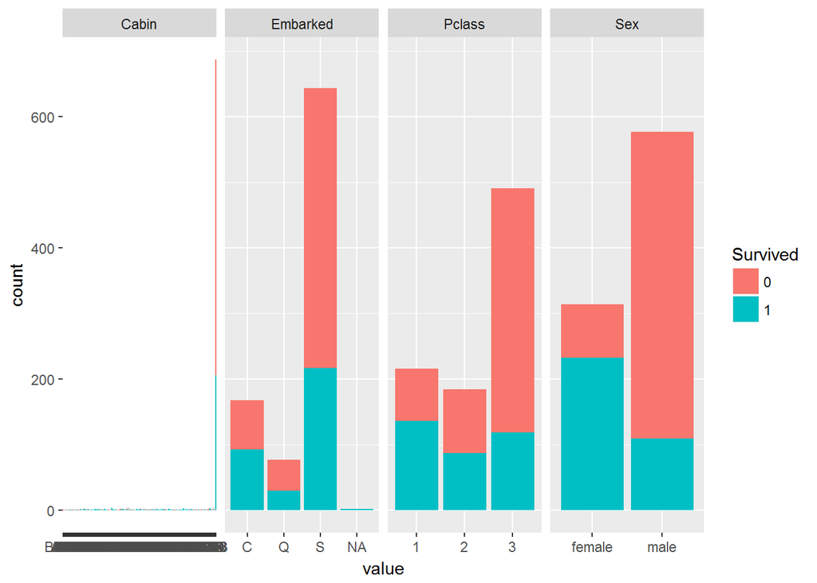

```r
#install.packages("ggplot2")
library(ggplot2)
qplot(x=value,data=df_tidy_factors,fill=Survived) + facet_grid(~feature,scales="free")
```

## plot for numerical columns

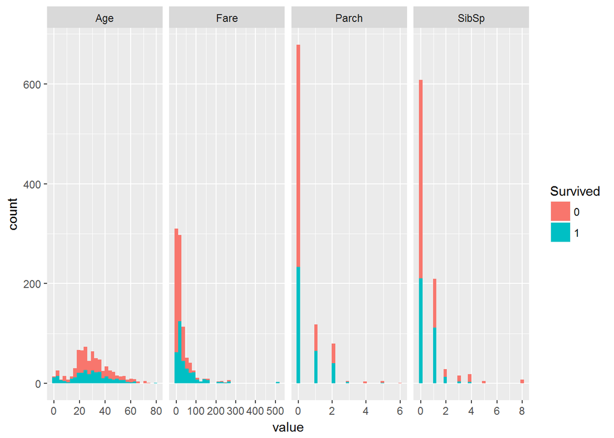

```r
qplot(x=value,data=df_tidy_numerics,fill=Survived) + facet_grid(~feature,scales="free")
```

### Model Creation Split the data into train and test sets

```r
rows<- nrow(df)
indices <- sample(1:rows,rows*0.8)
train<- df[indices,]
test<- df[-indices,]
```

## we trained the model:naive bayes, without using the caret library, on the train data set.

```r
#install.packages('e1071')
#load e1071 library and invoke naiveBayes method
library(e1071)
nb_model <- naiveBayes(Survived~.,data = train)
nb_model
```

```
##
## Naive Bayes Classifier for Discrete Predictors
##
## Call:
## naiveBayes.default(x = X, y = Y, laplace = laplace)
##
## A-priori probabilities:
## Y
##         0         1
## 0.6081461 0.3918539
##
## Conditional probabilities:
##    Pclass
## Y           1         2         3
##   0 0.1408776 0.1662818 0.6928406
##   1 0.3870968 0.2437276 0.3691756
##
##    Sex
## Y      female      male
##   0 0.1431871 0.8568129
##   1 0.6702509 0.3297491
##
##    Age
## Y       [,1]     [,2]
##   0 30.70633 14.18870
##   1 27.48523 14.69174
##
##    SibSp
## Y        [,1]      [,2]
##   0 0.5519630 1.3097576
##   1 0.4731183 0.6931016
##
##    Parch
## Y        [,1]      [,2]
##   0 0.3140878 0.8211386
##   1 0.4659498 0.7428957
##
##    Fare
## Y       [,1]     [,2]
##   0 21.67680 30.51579
```

[output cut: 112 more lines]

```
##   0 0.000000000 0.019230769 0.000000000 0.000000000 0.019230769
##   1 0.000000000 0.000000000 0.008928571 0.008928571 0.000000000
##    Cabin
## Y         F G73          F2         F33         F38          F4
##   0 0.038461538 0.019230769 0.000000000 0.019230769 0.000000000
##   1 0.000000000 0.017857143 0.017857143 0.000000000 0.017857143
##    Cabin
## Y            G6           T
##   0 0.019230769 0.019230769
##   1 0.017857143 0.000000000
##
##    Embarked
## Y            C          Q          S
##   0 0.13856813 0.08545035 0.77598152
##   1 0.29241877 0.08303249 0.62454874
```

## we predict the naive bayes model on the test data set, in the prediction process we pass the na fields in the data set, because the prediction does not succedd with na fields.

this prediction is in order to train our model, and to get better results.

```r
nb_test_predict <- predict(nb_model,test[,-1] ,na.action = na.pass)
```

## we Use a confusion matrix to evaluate the prediction results

```r
table(pred=nb_test_predict,true=test$Survived)
```

```
##     true
## pred   0   1
##    0 105  23
##    1  11  40
```

## Calculate the model’s test accuracy.

```r
mean(nb_test_predict==test$Survived)
```

```
## [1] 0.8100559
```

## load the test file, with na as “”

```r
new_df <-read.csv('C:/Users/אחיעד/Desktop/data science/ass2/Titanic/test.csv',na.strings = "")
```

## Create a vector with the PassengerIds of records in the test file.

```r
ids<- new_df$PassengerId
```

## remove features from new_df(the test file)

```r
new_df$Pclass<- as.factor(new_df$Pclass)
new_df<- new_df[,-c(1,3,8)]
```

## Another thing that is going to make troubles is that the test data contains some new levels in the *Cabin* feature that did not appear in the train data (you can check it by applying *Summary* on the test data). Add these new levels to the model.

### Getting the levels of the “Cabin” feature from a model *m*: m$xlevels[[“Cabin”]]

### Getting the levels of the “Cabin” feature from a dataframe *d*: levels(d$Cabin)

### Union operation: union(x,y)

```r
nb_model$xlevels[["Cabin"]] <- union(nb_model$xlevels[["Cabin"]], levels(new_df$Cabin))
```

## we predict the naive bayes model on the new_df data set, in the prediction process we pass the na fields in the data set, because the prediction does not succedd with na fields. this prediction is in order to predict the test.csv file.

```r
new_pred_nb_model<- predict(nb_model,new_df,na.action = na.pass)
```

### Write the *PassengerId* and *Survived* attributes to a csv file.

```r
res <- cbind(PassengerId=ids,Survived=as.character(new_pred_nb_model))
write.csv(res,file="C:/Users/אחיעד/Desktop/data science/ass2/prediction2/output.csv",row.names = F)
```